# Primeros pasos en R

5/29/2021

## RStudio. Ventanas y menú de opciones

[figure not shown]

## R

!Una calculadora con esteroides!

```r
(log(548) * log10(5)) - (exp(35 / 5) + pi^2 + sqrt(64))
```

```
## [1] -1110.095
```

```r
- 8 * 8
```

```
## [1] -64
```

```r
2 + -2
```

```
## [1] 0
```

## Algunos operadores básicos

**Matemáticos**

`+` suma, `-` resta, `*` multiplicación, `/` división, `^` exponencial.

**Lógicos**

`<` menor, `<=` menor o igual, `>` mayor, `>=` mayor o igual, `==` igual, `!=` differente, `!X` no x, `X|Y` X o Y, `X&Y` X y Y.

Ya veremos cómo se emplean los operadores lógicos…

## Creando objetos

R es un lenguaje de programación orientado a objetos. Es decir, creamos objetos al asignar datos o funciones a nombres particulares.

nombre `<-` datos o función

Símbolos de asignación: `<-` o `=`.

```r
curso <- "clinica de datos"
curso # ejecutamos "curso" para verificar el elemento asignado
```

```
## [1] "clinica de datos"
```

```r
# Cualquier escrito que antecede un `#` es entendido por R
# como un comentario que no afecta el código.
```

## `=` o `<-` funcionan igual como símbolos de asignación, peeero…

```r
curso <- "clinica de datos"
```

```r
curso = "clinica de datos"
```

Son lo mismo. Sin embargo, `=` también se emplea para asignar valores a los argumentos en las funciones, mientras `<-` solo se usa como símbolo de asignación.

e.g.

```r
mean(c(1, 2, 3, NA), na.rm = TRUE)
```

Paciencia, pronto tendrá más sentido.

## entonces

[figure not shown]

## Vectores

Estructura básica y fundamental en la que se organizan los datos en R.

```r
x <- 8    # un vector puede contener desde 1 hasta n elementos.

          # "length()" se usa para determinar la longitud o
length(x) # el número de elementos que tiene un objeto
```

```
## [1] 1
```

```r
y <- c(5, 1, 8, 22, 15021, 0.003) # La función concatenar "c()"
                               # se usa para agrupar elementos.
#Los elementos se separan con "," y los decimales SIEMPRE se denotan con "."
length(y) # En este caso cada número corresponde a un elemento
```

```
## [1] 6
```

## Clases de vectores

```r
x <- c(5, 1, 8, 22, 15021, 0.003); class(x)
```

```
## [1] "numeric"
```

```r
y <- c("jkgjh", "5gh54fb", "4h-k"); class(y)
```

```
## [1] "character"
```

```r
z <- as.factor(c("grande", "mediano", "pequeño")); class(z)
```

```
## [1] "factor"
```

```r
l <- c(TRUE, TRUE, FALSE, TRUE, FALSE, FALSE); class(l)
```

```
## [1] "logical"
```

## Indexando vectores

Cada elemento en un vector conserva una posición numérica específica a la que se puede hacer referencia usando corchetes

```r
x
```

```
## [1]     5.000     1.000     8.000    22.000 15021.000     0.003
```

```r
x[1]
```

```
## [1] 5
```

```r
x[c(1, 3:5)]
```

```
## [1]     5     8    22 15021
```

## Agregar y eliminar elementos de un vector

Usando los indices de cada elemento en el vector

```r
x <- c(5, 1, 8, 22, 15021, 0.003)

x[-5]  # elimina el elemento que se encuentra en la posición 5.
```

```
## [1]  5.000  1.000  8.000 22.000  0.003
```

```r
x <- c(x, 55, 0, -4) # para agregar elementos se usa la función concatenar,
                     # se recicla el vector, se agregan los elementos y
                     # se asigna de nuevo al nombre x.
x
```

```
## [1]     5.000     1.000     8.000    22.000 15021.000     0.003    55.000
## [8]     0.000    -4.000
```

## Ahora…

Puede realizar la misma operación con operadores lógicos estableciendo alguna condición sobre el elemento a eliminar o filtrar.

```r
x[x >= 1 & x < 100]
```

```
## [1]  5  1  8 22 55
```

Internamente R evalúa si cada elemento del vector cumple la condición `x>=1 & x<100`, así:

```r
x >= 1 & x < 100
```

```
## [1]  TRUE  TRUE  TRUE  TRUE FALSE FALSE  TRUE FALSE FALSE
```

## Matrices

En esencia son vectores con dos dimensiones, columnas y filas. Solo pueden ser compuestas por un tipo de elemento (e.g., numérico, caracter, lógico).

```r
x <- matrix(seq(from = 1, to = 50, by = 2), ncol = 5, nrow = 5)
x
```

```
##      [,1] [,2] [,3] [,4] [,5]
## [1,]    1   11   21   31   41
## [2,]    3   13   23   33   43
## [3,]    5   15   25   35   45
## [4,]    7   17   27   37   47
## [5,]    9   19   29   39   49
```

```r
# funciones ncol(), nrow() y dim()
```

## Indexación de matrices

Pueden indexarce los elementos por sus coordenadas o por su secuencia en la matriz. Por ejemplo en la matriz `x`:

```r
x[6] # para indexar el número 11 podemos indicar su posición en el vector
```

```
## [1] 11
```

```r
        # o indicar su coordenada con respecto a
x[1, 2] #la fila y columna (x[fila, columna])
```

```
## [1] 11
```

```r
x[, 1] # o seleccionar una columna completa.
```

```
## [1] 1 3 5 7 9
```

## Data frame

los data frames pueden ser vistos como una lista de vectores. El único requisito es que tengan la misma longitud.

```r
df <- data.frame(edad = sample(x = 1:100, size = 5),
                 nombre = c("natalia", "julian", "jenny", "erika", "paulo"),
                 sexo = as.factor(c("f", "m", "f", "f", "m")))
df
```

```
##   edad  nombre sexo
## 1   17 natalia    f
## 2   81  julian    m
## 3   60   jenny    f
## 4   26   erika    f
## 5   45   paulo    m
```

```r
# Explore las funciones names(), colnames(),
# nrow(), ncol(), dim(), length() y object.size()
```

## Explorando DF

```r
summary(df)
```

```
##       edad         nombre          sexo
##  Min.   :17.0   Length:5           f:3
##  1st Qu.:26.0   Class :character   m:2
##  Median :45.0   Mode  :character
##  Mean   :45.8
##  3rd Qu.:60.0
##  Max.   :81.0
```

```r
str(df)
```

```
## 'data.frame':    5 obs. of  3 variables:
##  $ edad  : int  17 81 60 26 45
##  $ nombre: chr  "natalia" "julian" "jenny" "erika" ...
##  $ sexo  : Factor w/ 2 levels "f","m": 1 2 1 1 2
```

## Extraer vectores o variables del DF

Hay cuatro formas con distintas implicaciones.

```r
df[1]   # Extrae la columna conservando la clase
```

```
##   edad
## 1   17
## 2   81
## 3   60
## 4   26
## 5   45
```

```r
df[[1]] # Extrae la información en forma de vector
```

```
## [1] 17 81 60 26 45
```

## …

```r
df[, 1] # Usando notación de matriz
```

```
## [1] 17 81 60 26 45
```

```r
df$edad # Especificando el nombre de la variable con el símbolo "$"
```

```
## [1] 17 81 60 26 45
```

Su uso dependerá de la función y el propósito del código que estén desarrollando.

## Extrayendo subconjuntos en un DF

Se pueden emplear dos métodos

```r
df[df$edad >= 20 &
     df$sexo == "f", ] # Usando notación de matrices y operadores lógicos
```

```
##   edad nombre sexo
## 3   60  jenny    f
## 4   26  erika    f
```

```r
subset(x = df, df$edad >= 20 &
         df$sexo == "f") # o empleando la función subset()
```

```
##   edad nombre sexo
## 3   60  jenny    f
## 4   26  erika    f
```

PD — !DF y matrices se indexan igual!

## Aplicando funciones a DF

```r
sum(x = df$edad) # calcula la suma de todas las edades
```

```
## [1] 229
```

```r
mean(x = df[[1]], na.rm = TRUE) # calcula el promedio
```

```
## [1] 45.8
```

Los argumentos en las funciones —como `x=` y `na.rm=` en la función `mean()`— definen su comportamiento. Pueden controlar objetos, operaciones lógicas y no tienen que ser explicitados en la función.

## Listas

Son estructuras de datos que pueden albergar vectores, matrices, DF e incluso otras listas.

```r
lista <- list(c(rnorm(5)), df) # la función list() agrupa el
                               # vector "c(rnorm(5))" y el data frame df

lista
```

```
## [[1]]
## [1]  0.01878705 -0.16500383  0.18258783 -0.98237066 -2.09279813
##
## [[2]]
##   edad  nombre sexo
## 1   17 natalia    f
## 2   81  julian    m
## 3   60   jenny    f
## 4   26   erika    f
## 5   45   paulo    m
```

La indexación de listas es solo un poco más compleja, Hadley Wickham lo resume de esta manera.

[figure not shown]

## Primeros Gráficos. La función `plot()`

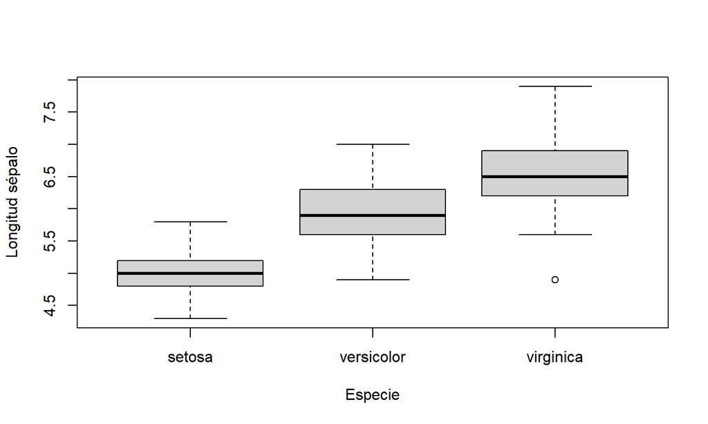

```r
plot(iris$Species, iris$Sepal.Length, ylab = "Longitud sépalo", xlab = "Especie")
```

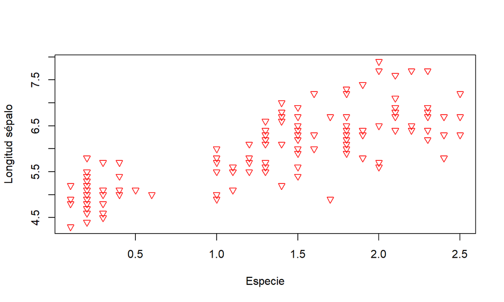

```r
plot(iris$Petal.Width, iris$Sepal.Length,
     ylab = "Longitud sépalo", xlab = "Especie", col = "red", pch = 6)
```

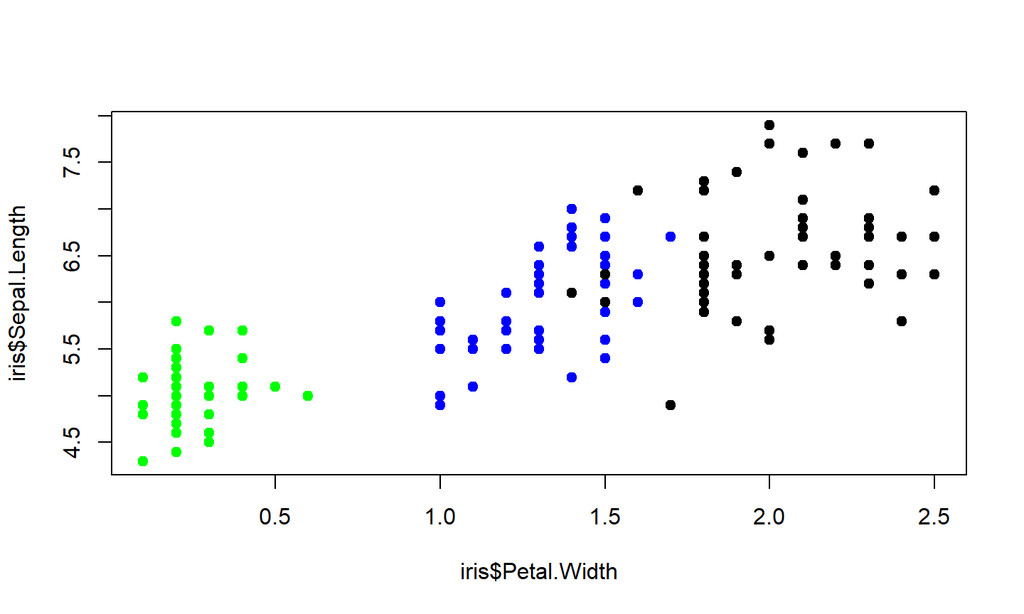

```r
plot(iris$Petal.Width, iris$Sepal.Length,
     col = ifelse(iris$Species == "setosa", "green",
                    ifelse(iris$Species == "virginica",
                           "black", "blue")), pch = 19)
```

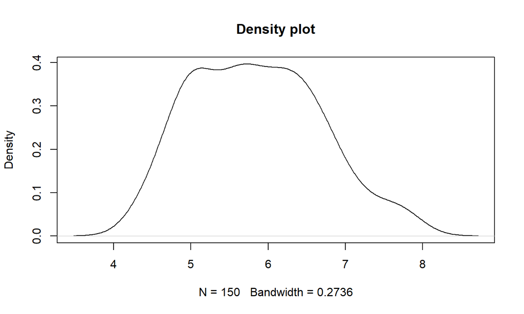

```r
plot(density(iris$Sepal.Length), main = "Density plot")
```

## Instalar y cargar paquetes

Los paquetes son conjuntos de funciones que han sido disponibilizadas a través del CRAN para su uso público.

```r
install.packages("paquete") # Instalar paquete
library(paquete) # Cargar paquete
require(paquete) # También se usa para cargar
```

```r
citation(package = "ggplot2") # para citar un paquete
```

```
##
##
##   H. Wickham. ggplot2: Elegant Graphics for Data Analysis.
##   Springer-Verlag New York, 2016.
##
## A BibTeX entry for LaTeX users is
##
##   @Book{,
##     author = {Hadley Wickham},
##     title = {ggplot2: Elegant Graphics for Data Analysis},
##     publisher = {Springer-Verlag New York},
##     year = {2016},
##     isbn = {978-3-319-24277-4},
##     url = {https://ggplot2.tidyverse.org},
##   }
```

## Buscando ayuda!

[figure not shown]

```r
?ggplot2        # ayuda específica
??ggplot2       # términos relacionados
help("ggplot2") # similar a la primera
```

## mas ayudas…

Pueden consultar los argumentos de una función

```r
args(ggplot)
```

```
## function (data = NULL, mapping = aes(), ..., environment = parent.frame())
## NULL
```

o solicitarle a R ejemplos de su uso!

```r
example("mean")
```

```
##
## mean> x <- c(0:10, 50)
##
## mean> xm <- mean(x)
##
## mean> c(xm, mean(x, trim = 0.10))
## [1] 8.75 5.50
```